# Homework 1

Author

Kálmán Abari

# Solution of Homework 1

## The choosen article

- **DOI:** https://doi.org/10.3389/fpsyg.2014.00907
- **Title:** Future directions in precognition research: more research can bridge the gap between skeptics and proponents
- **Author(s):**
  1. Michael S. Franklin
  2. Stephen L. Baumgart
  3. Jonathan W. Schooler
- **Publication date:** 22 August 2014
- **Volume:** 5

## From the article[^1]

### INTRODUCTION

Although claims of precognition have been prevalent across human history, it is no surprise that these assertions have been met with strong skepticism. Precognition, *the ability to obtain information about a future event, unknowable through inference alone, before the event actually occurs*, conflicts with the fundamental subjective experience of time asymmetrically flowing from past to future, brings into question the notion of free will, and contends with steadfast notions of cause and effect. Despite these reasons for skepticism, researchers have pursued this topic, and a large database of studies conducted under controlled laboratory conditions now exist. This work roughly spans from the 1930’s (e.g., Rhine, 1938) up to this day (Bem, 2011; Mossbridge et al., 2014; Rabeyron, 2014). The accumulated evidence includes significant meta-analyses of forced-choice guessing experiments (Honorton and Ferrari, 1989), presentiment experiments (Mossbridge et al., 2012), and recent replications from Bem (2011, discussed below; Bem et al., 2014)

### PHYSICAL IMPLAUSIBILITY

It is not unexpected that psychologists are most skeptical of precognition (Wagner and Monnet, 1979). This is likely due to their knowledge of the many illusions and biases that influence perception and memory. However, putting these cognitive biases aside, this work is often dismissed out of hand under the assumption that precognition would require overturning basic and essential physical and psychological tenets. Schwarzkopf (2014) illustrates this position:

> “. . . the seismic nature of these claims cannot be overstated: future events influencing the past breaks the second law of thermodynamics. . . It also completely undermines over a century of experimental research based on the assumption that causes precede effects”

## Tables and images

table

| Information | Type | Value |
| --- | --- | --- |
| References | Number | 31 |
| Pages | Number | 4 |
| Type of article | Text | Opinion article |

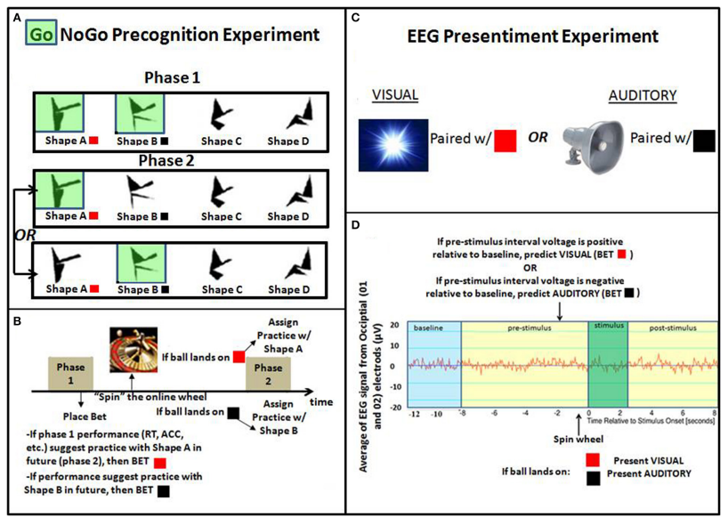

image

## Footnotes

[^1]: Copying text. Avoid the plagiarism trap in our own academic writing.